# Simulation-based calibration checking in model development workflow

Author

Martin Modrák

Published

2022-12-16

Modified

2026-06-17

This notebook includes the code for the Bayesian Workflow book Chapter 31 *Simulation-based calibration checking in model development workflow*.

# 1 Introduction

Here we describe a complete process to iteratively build and validate the *implementation* of a non-trivial, but still relatively small model using simulation based calibration checking (SBC, Modrák et al. (2025)). This is not a full Bayesian Workflow, instead the process described here can be thought of as a subroutine in the full workflow: here we take a relatively precise description of a model as input and try to produce a Stan program that implements this model. Once we have a Stan program we trust, it is still necessary to validate its fit to actual data and other properties, which may trigger a need to change the model. At this point you may want to go back to simulations and make sure the modified model is implemented correctly.

The workflow described here focuses on small models. “Small” means that the model is relatively fast to fit and we don’t have to worry about computation too much. Still many of the approaches here also apply to complex models (especially starting small and building smaller submodels separately), and with proper separation of the model into submodels, one can validate big chunks of Stan code while working with small models only.

We expect the reader to be familiar with basics of the SBC package. If not, check out the [*Getting Started with SBC* vignette](https://hyunjimoon.github.io/SBC/articles/SBC.html).

## 1.1 Example model

The example we’ll investigate is building a two-component Poisson mixture, where the mixing ratio is allowed to vary with some predictors while the means of the components are the same for all observations. A somewhat contrived real world situation where this could be a useful model: there are two sub-species of an animal that are hard to observe directly, but leave droppings (poop) behind, that we can find. Further, we know the subspecies differ in the average number of droppings they leave at one place. So we can take the number of droppings as a noisy information about which subspecies was present at given location. We observe the number of droppings at multiple locations and record some environmental covariates about the locations (e.g. temperature, altitude) and want to learn something about the association between those covariates and the prevalence of either subspecies.

A mathematical description would be:

$$\begin{align*}
y_i &\sim \mathrm{Poisson}(\mu_{z_i}) \\
z_i &\sim \mathrm{Bernoulli}(\mathrm{logit}^{-1}(\theta_i)) \\
\theta_i &= \alpha + \sum_k \beta_k \mathbf{X}_{i,k} \\
\log \mu_{\{1,2\}} &\sim \mathrm{N(3, 1)} \\
\alpha &\sim N(0, 2) \\
\beta_k &\sim N(0, 1)
\end{align*}$$

This model naturally decomposes into two submodels:

1. the mixture submodel where the mixing ratio is the same for all observations
2. a logistic regression submodel where we take the covariates and make a prediction of a probability, assuming we (noisily) observe the probability.

It is good practice to start small and implement and validate each of those submodels separately and then put them together and validate the bigger model. This makes it substantially easier to locate bugs. You’ll notice that the process ends up involving a lot of steps, but the fact is that we still ignore all the completely invalid models we created while writing this vignette (typos, compile errors, dimension mismatches, …). Developing models you can trust is hard work. More experienced users can definitely make bigger steps at once, but we strongly discourage anyone from writing a big model in one go.

## 1.2 Setup

Let’s setup and get our hands dirty.

````r
library(rprojroot)
root <- has_file(".Bayesian-Workflow-root")$make_fix_file()
# remotes::install_github("hyunjimoon/SBC")
library(SBC)
options(SBC.min_chunk_size = 5)
library(cmdstanr)
library(posterior)
options(pillar.neg = FALSE,
        pillar.subtle = FALSE,
        pillar.sigfig = 2)
library(ggplot2)
library(bayesplot)
theme_set(bayesplot::theme_default(base_family = "sans"))
library(patchwork) # Needed only for saving plots for the book
library(future)
plan(multisession)

print_stan_file <- function(file) {
  code <- readLines(file)
  if (isTRUE(getOption("knitr.in.progress")) &
        identical(knitr::opts_current$get("results"), "asis")) {
    # In render: emit as-is so Pandoc/Quarto does syntax highlighting
    block <- paste0("```stan", "\n", paste(code, collapse = "\n"), "\n", "```")
    knitr::asis_output(block)
  } else {
    writeLines(code)
  }
}

# Setup caching of results
cache_dir <- root("sbc", "_cache")
if (!dir.exists(cache_dir)) {
  dir.create(cache_dir)
}
````

# 2 Mixture submodel

There is a good [guide to mixtures](https://mc-stan.org/docs/stan-users-guide/finite-mixtures.html) in the Stan user’s guide. Following the user’s guide would save us from a lot of mistakes, but for the sake of example, we will pretend we didn’t really read it - and we’ll see the problems can be discovered via simulations.

So this is our first try at implementing the mixture submodel:

```r
code_first <- root("sbc", "models/mixture_first.stan")
```

```r
print_stan_file(code_first)
```

```stan
data {
  int<lower=0> N;
  array[N] int y;
}
parameters {
  real mu1;
  real mu2;
  real<lower=0, upper=1> theta;
}
model {
  target += log_mix(theta, poisson_log_lpmf(y | mu1), poisson_log_lpmf(y | mu2));
  target += normal_lpdf(mu1 | 3, 1);
  target += normal_lpdf(mu2 | 3, 1);
}
```

```r
model_first <- cmdstan_model(code_first)
backend_first <- SBC_backend_cmdstan_sample(model_first)
```

And this is our code to simulate data for this model:

```r
generator_func_first <- function(N) {
  mu1 <- rnorm(1, 3, 1)
  mu2 <- rnorm(1, 3, 1)
  theta <- runif(1)

  y <- numeric(N)
  for (n in 1:N) {
    if (runif(1) < theta) {
      y[n] <- rpois(1, exp(mu1))
    } else {
      y[n] <- rpois(1, exp(mu2))
    }
  }
  list(variables = list(mu1 = mu1,
                        mu2 = mu2,
                        theta = theta),
       generated = list(N = N,
                        y = y))
}
generator_first <- SBC_generator_function(generator_func_first, N = 50)
```

Let’s start with just a single simulation:

```r
set.seed(68455554)
datasets_first <- generate_datasets(generator_first, 1)
results_first <- compute_SBC(datasets_first, backend_first,
                             cache_mode = "results",
                             cache_location = file.path(cache_dir, "mixture_first"))
```

```
Results loaded from cache file 'mixture_first'
```

```
 - 1 (100%) fits had divergences. Maximum number of divergences was 9.
```

```
 - 1 (100%) fits had maximum Rhat > 1.01. Maximum Rhat was 1.208.
```

```
 - 1 (100%) fits had tail ESS / maximum rank < 0.5. Minimum tail ESS / maximum rank was 0.03. This potentially skews the rank statistics.
    If the fits look good otherwise, increasing `thin_ranks` (via recompute_SBC_statistics)
   or number of posterior draws (by refitting) might help.
```

```
Not all diagnostics are OK.
You can learn more by inspecting $default_diagnostics, $backend_diagnostics
and/or investigating $outputs/$messages/$warnings for detailed output from the backend.
```

There are divergences. Let’s examine the MCMC pairs plots:

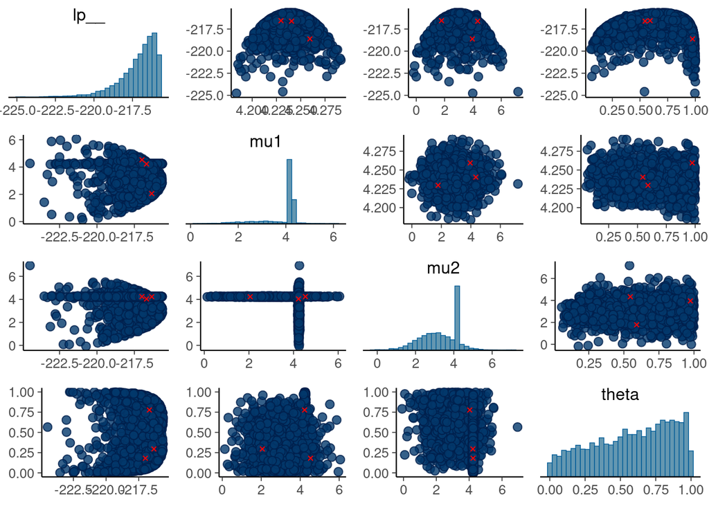

Figure 1: Pairs plot for our first attempt at the mixture component.

```r
# Fixing the condition for above/over diagonal chains, in a minority
# of runs the plot shows the problem less clearly, as discussed at
# https://github.com/stan-dev/bayesplot/issues/132
p_cond <- pairs_condition(chains = list(c(1, 3), c(2, 4)))
mixture_first_pairs <- mcmc_pairs(results_first$fits[[1]]$draws(),
                                  condition = p_cond,
                                  np = nuts_params(results_first$fits[[1]]))
mixture_first_pairs
```

One thing that stands out is that either `mu1` is tightly determined and `mu2` is allowed the full prior range or the other way around. We also don’t learn anything about theta.

This might be puzzling but relates to bad usage of `log_mix`. The thing is that `poisson_log_lpmf(y | mu1)` returns a single number - the total log likelihood of all elements of `y` given `mu1`. And thus we are building a mixture where either all observations are from the first component or all are from the second component. To implement mixture where each observation is allowed to come from a different component, we need to loop over observations and do a separate `log_mix` call for each.

More details on the mathematical background are explained in the [“Vectorizing mixtures”](https://mc-stan.org/docs/stan-users-guide/finite-mixtures.html#vectorizing-mixtures) section of Stan User’s guide.

## 2.1 Fixed mixture model

We make a new model fixing the `log_mix` problem.

```r
code_fixed_log_mix <- root("sbc", "models/mixture_fixed_log_mix.stan")
```

```r
print_stan_file(code_fixed_log_mix)
```

```stan
data {
  int<lower=0> N;
  array[N] int y;
}
parameters {
  real mu1;
  real mu2;
  real<lower=0, upper=1> theta;
}
model {
  for(n in 1:N) {
    target += log_mix(theta,
                      poisson_log_lpmf(y[n] | mu1),
                      poisson_log_lpmf(y[n] | mu2));
  }
  target += normal_lpdf(mu1 | 3, 1);
  target += normal_lpdf(mu2 | 3, 1);
}
```

```r
model_fixed_log_mix <- cmdstan_model(code_fixed_log_mix)
backend_fixed_log_mix <- SBC_backend_cmdstan_sample(model_fixed_log_mix)
```

So let’s try once again with the same single simulation:

```r
results_fixed_log_mix <- compute_SBC(datasets_first,
                                     backend_fixed_log_mix,
                                     cache_mode = "results",
                                     cache_location = file.path(cache_dir, "mixture_fixed_log_mix"))
```

```
Results loaded from cache file 'mixture_fixed_log_mix'
```

```
 - 1 (100%) fits had maximum Rhat > 1.01. Maximum Rhat was 2.123.
```

```
 - 1 (100%) fits had tail ESS / maximum rank < 0.5. Minimum tail ESS / maximum rank was 0.04. This potentially skews the rank statistics.
    If the fits look good otherwise, increasing `thin_ranks` (via recompute_SBC_statistics)
   or number of posterior draws (by refitting) might help.
```

```
Not all diagnostics are OK.
You can learn more by inspecting $default_diagnostics, $backend_diagnostics
and/or investigating $outputs/$messages/$warnings for detailed output from the backend.
```

```r
print(results_fixed_log_mix$stats, digits = 2)
```

```
  sim_id variable simulated_value rank z_score mean   sd    q5 median  q95 rhat
1      1      mu1           3.125  196   -0.33  3.4 0.86 2.217    3.7 4.28  2.1
2      1      mu2           4.270  359    0.99  3.4 0.87 2.218    3.8 4.28  2.1
3      1    theta           0.053  158   -0.97  0.5 0.46 0.011    0.5 0.99  2.1
  ess_bulk ess_tail attributes max_rank has_na all_na all_inf
1      1.3       15                 399  FALSE  FALSE   FALSE
2      1.3       17                 399  FALSE  FALSE   FALSE
3      1.3       17                 399  FALSE  FALSE   FALSE
```

We see nothing obviously wrong, the posterior means are relatively close to simulated values (as summarised by the z-scores) - no variable is clearly ridiculously misfit. So let’s run a few more iterations.

```r
set.seed(8314566)
datasets_first_10 <- generate_datasets(generator_first, 10)

results_fixed_log_mix_2 <- compute_SBC(datasets_first_10,
                                       backend_fixed_log_mix,
                                       cache_mode = "results",
                                       cache_location = file.path(cache_dir, "mixture_fixed_log_mix_2"))
```

```
Results loaded from cache file 'mixture_fixed_log_mix_2'
```

```
 - 6 (60%) fits had maximum Rhat > 1.01. Maximum Rhat was 1.219.
```

```
 - 6 (60%) fits had tail ESS / maximum rank < 0.5. Minimum tail ESS / maximum rank was 0.03. This potentially skews the rank statistics.
    If the fits look good otherwise, increasing `thin_ranks` (via recompute_SBC_statistics)
   or number of posterior draws (by refitting) might help.
```

```
Not all diagnostics are OK.
You can learn more by inspecting $default_diagnostics, $backend_diagnostics
and/or investigating $outputs/$messages/$warnings for detailed output from the backend.
```

So there are some problems - we have quite a bunch of high R-hat and low ESS values. This is the distribution of all rhats:

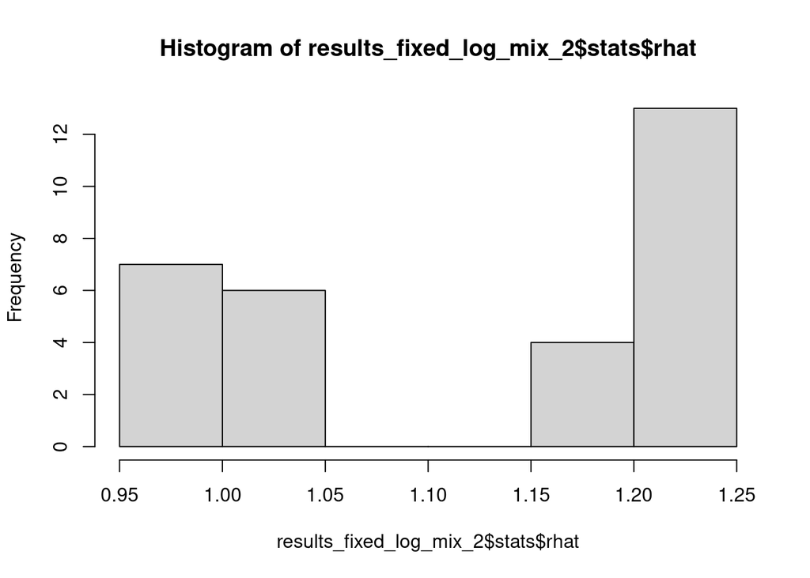

Figure 2: Distribution of $\widehat{R}$ statistic for the fits of the mixture component after fixing the first bug.

```r
hist(results_fixed_log_mix_2$stats$rhat)
```

Let’s examine a single pairs plot:

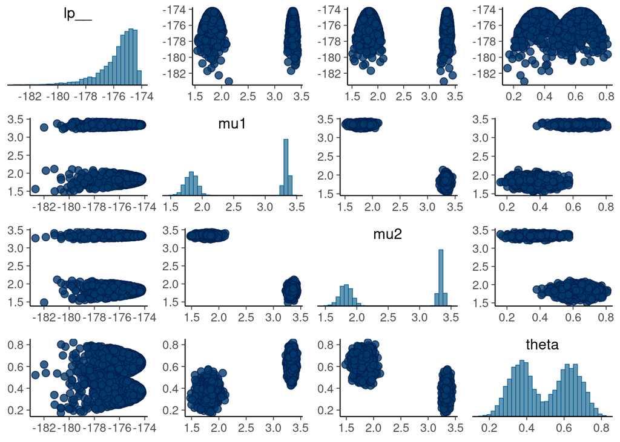

Figure 3: A pairs plot for one of the problematic fits.

```r
mixture_fixed_log_mix_pairs <- mcmc_pairs(results_fixed_log_mix_2$fits[[1]]$draws())
mixture_fixed_log_mix_pairs
```

We clearly see two modes in the posterior. And upon reflection, we can see why: swapping `mu1` with `mu2` while also changing `theta` for `1 - theta` gives *exactly* the same likelihood - because the ordering does not matter. A more detailed explanation of this type of problem is at https://betanalpha.github.io/assets/case_studies/identifying_mixture_models.html

## 2.2 Fixed parameter ordering

We can easily fix the ordering of the `mu`s by using the `ordered` built-in type.

```r
code_fixed_ordered <- root("sbc", "models/mixture_fixed_ordered.stan")
```

```r
print_stan_file(code_fixed_ordered)
```

```stan
data {
  int<lower=0> N;
  array[N] int y;
}
parameters {
  ordered[2] mu;
  real<lower=0, upper=1> theta;
}
model {
  for(n in 1:N) {
    target += log_mix(theta,
                      poisson_log_lpmf(y[n] | mu[1]),
                      poisson_log_lpmf(y[n] | mu[2]));
  }
  target += normal_lpdf(mu | 3, 1);
}
```

```r
model_fixed_ordered <- cmdstan_model(code_fixed_ordered)
backend_fixed_ordered <- SBC_backend_cmdstan_sample(model_fixed_ordered)
```

We also need to update the generator to match the new names and ordering constant:

```r
generator_func_ordered <- function(N) {
  # If the priors for all components of an ordered vector are the same
  # then just sorting the result of a generator is enough to create
  # a valid draw from the ordered vector prior
  mu <- sort(rnorm(2, 3, 1))
  theta <- runif(1)
  y <- numeric(N)
  for (n in 1:N) {
    if (runif(1) < theta) {
      y[n] <- rpois(1, exp(mu[1]))
    } else {
      y[n] <- rpois(1, exp(mu[2]))
    }
  }
  list(variables = list(mu = mu, theta = theta),
       generated = list(N = N, y = y))
}
generator_ordered <- SBC_generator_function(generator_func_ordered, N = 50)
```

We are kind of confident (and the model fits quickly), so we’ll already start with 10 simulations.

```r
set.seed(3785432)
datasets_ordered_10 <- generate_datasets(generator_ordered, 10)

results_fixed_ordered <- compute_SBC(datasets_ordered_10,
                                     backend_fixed_ordered,
                                     cache_mode = "results",
                                     cache_location = file.path(cache_dir, "mixture_fixed_ordered"))
```

```
Results loaded from cache file 'mixture_fixed_ordered'
```

```
 - 2 (20%) fits had divergences. Maximum number of divergences was 55.
```

```
 - 2 (20%) fits had maximum Rhat > 1.01. Maximum Rhat was 1.033.
```

```
 - 2 (20%) fits had tail ESS / maximum rank < 0.5. Minimum tail ESS / maximum rank was 0.03. This potentially skews the rank statistics.
    If the fits look good otherwise, increasing `thin_ranks` (via recompute_SBC_statistics)
   or number of posterior draws (by refitting) might help.
```

```
Not all diagnostics are OK.
You can learn more by inspecting $default_diagnostics, $backend_diagnostics
and/or investigating $outputs/$messages/$warnings for detailed output from the backend.
```

Now some fits still produce problematic Rhats or divergent transitions, let’s browse the `$backend_diagnostics` (which contain Stan-specific diagnostic values) to see which simulations are causing problems:

```r
print(results_fixed_ordered$backend_diagnostics, digits = 2)
```

```
   sim_id max_chain_time n_failed_chains n_divergent n_max_treedepth min_bfmi
1       1           0.39               0          17               0     0.75
2       2           0.51               0          55               0     0.86
3       3           0.38               0           0               0     0.98
4       4           0.33               0           0               0     0.97
5       5           1.99               0           0               0     1.04
6       6           0.46               0           0               0     0.99
7       7           0.35               0           0               0     1.04
8       8           0.38               0           0               0     1.09
9       9           0.23               0           0               0     0.94
10     10           0.28               0           0               0     0.92
   n_rejects
1          0
2          0
3          0
4          0
5          0
6          0
7          0
8          0
9          0
10         0
```

One of the fits has quite a lot of divergent transitions. Let’s look at the pairs plot for the model:

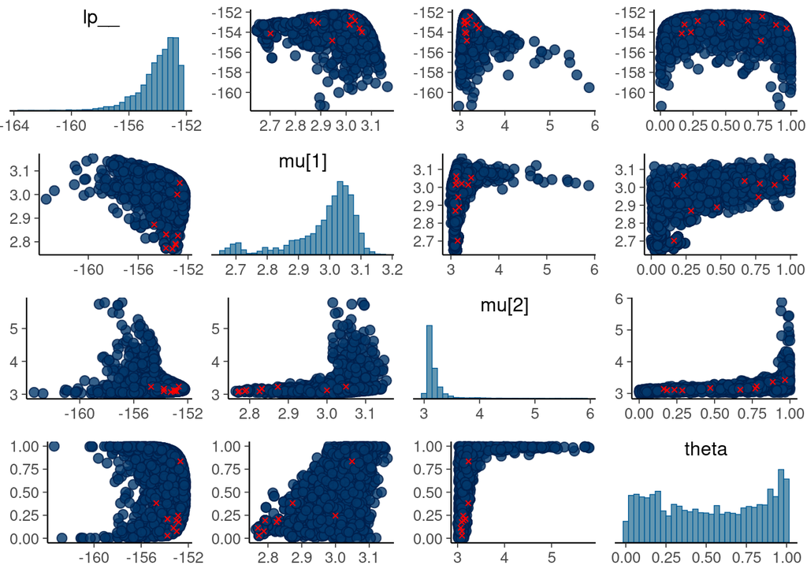

Figure 4: Pairs plot of a problematic fit in mixture model with ordered components.

```r
problematic_fit_id <- 2
problematic_fit <- results_fixed_ordered$fits[[problematic_fit_id]]
mixture_fixed_ordered_pairs <- mcmc_pairs(problematic_fit$draws(),
                                          np = nuts_params(problematic_fit))
mixture_fixed_ordered_pairs
```

There is a lot of ugly stuff going on. Notably, one can notice that the posterior of theta is bimodal, preferring either almost 0 or almost 1 - and when that happens, the mean of one of the components is almost unconstrained. Why does that happen? The key to the answer is in the simulated values for the component means:

```r
subset_draws(datasets_ordered_10$variables, draw = problematic_fit_id)
```

```
# A draws_matrix: 1 iterations, 1 chains, and 3 variables
    variable
draw mu[1] mu[2] theta
   2   3.1   3.1  0.65
```

We were unlucky enough to simulate data where both components have almost the same mean and thus we are actually looking at data that is not really a mixture. Mixture models can misbehave badly in such cases (see once again the [case study by Michael Betancourt](https://betanalpha.github.io/assets/case_studies/identifying_mixture_models.html#5_singular_components_and_computational_issues) for a bit more detailed dive into this particular problem).

## 2.3 Fixing degenerate components?

What to do about this? Fixing the model to handle such cases gracefully is hard. But the problem is basically our prior - we want to express that (since we are fitting a two component model), we don’t expect the means to be too similar. So if we can change our simulation to avoid this, we’ll be able to proceed with SBC. If such a pattern appeared in real data, we would still have a problem, but we would notice thanks to the diagnostics.

This can definitely be done. But another way is to just ignore the simulations that had divergences for SBC calculations. It turns out that if we remove simulations in a way that only depends on the observed data (and not on unobserved variables), the SBC identity is preserved and we can use SBC without modifications. The resulting check is however telling us something only for data that were not rejected. In this case this is not a big issue: if a fit had divergent transitions, we would not trust it anyway, so removing fits with divergent transitions is not such a big deal.

For more details see the [`rejection_sampling`](https://hyunjimoon.github.io/SBC/articles/rejection_sampling.html) vignette in the SBC package.

So let us subset the results to avoid divergences:

```r
sim_ids_to_keep <-
  results_fixed_ordered$backend_diagnostics$sim_id[
    results_fixed_ordered$backend_diagnostics$n_divergent == 0]
# Equivalent tidy version if you prefer
# sim_ids_to_keep <- results_fixed_ordered$backend_diagnostics %>%
#   dplyr::filter(n_divergent == 0) %>%
#   dplyr::pull(sim_id)
results_fixed_ordered_subset <- results_fixed_ordered[sim_ids_to_keep]
summary(results_fixed_ordered_subset)
```

```
SBC_results with 8 total fits.
 - [OK] No fits produced error.
 - [OK] No fits gave warning.
 - [INFO] Maximum time per chain was 2.
 - [OK] No fits had failed chains.
 - [OK] No fits had divergences.
 - [OK] No fits had iterations that saturated max treedepth.
 - [OK] All fits had E-BFMI >= 0.2. Minimum E-BFMI was 0.919.
 - [OK] No fits had steps rejected.
 - [OK] All fits had maximum Rhat <= 1.01. Maximum Rhat was 1.002.
 - [INFO] Minimum bulk ESS was 1036.
 - [INFO] Minimum tail ESS was 1353.
 - [OK] All fits had tail ESS / maximum rank >= 0.5. Minimum tail ESS / maximum rank was 3.39.
```

This gives us no obvious problems.

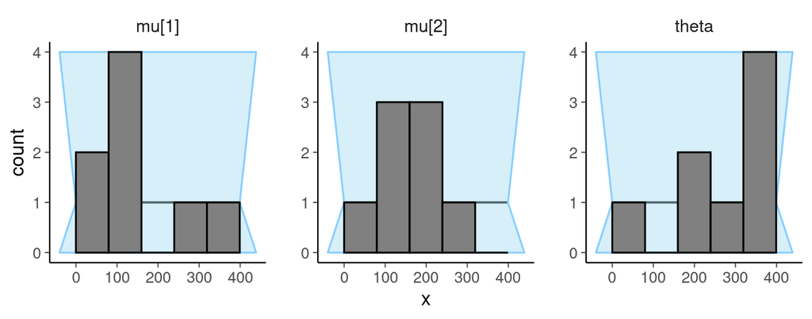

Figure 5: Rank histograms for the simulations where there were no divergecnces

```r
plot_rank_hist(results_fixed_ordered_subset)
```

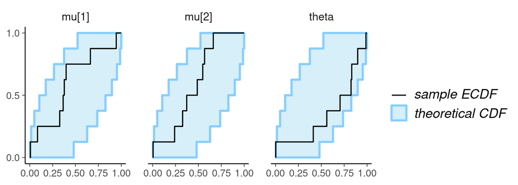

Figure 6: ECDF plots for the simulations where there were no divergences

```r
plot_ecdf(results_fixed_ordered_subset)
```

Since we now have only 8 simulations, it is not surprising that we are still left with a huge uncertainty about the actual coverage of our posterior intervals - we can see that in a plot:

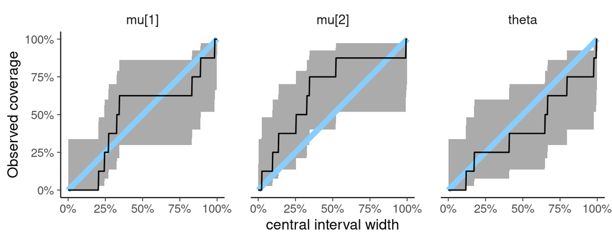

Figure 7: Nominal (light blue) and observed (black) coverage of central posterior intervals for the simulations where there were no divergecnces

```r
plot_coverage(results_fixed_ordered_subset)
```

The coverage plot shows the observed coverage of central posterior intervals of varying width and the associated uncertainty (black + grey), the blue line represents perfect calibration.

Or investigate numerically.

```r
coverage <- empirical_coverage(results_fixed_ordered_subset$stats,
                               width = c(0.5, 0.9, 0.95))
coverage
```

```
# A tibble: 9 × 6
  variable width width_represented ci_low estimate ci_high
  <chr>    <dbl>             <dbl>  <dbl>    <dbl>   <dbl>
1 mu[1]     0.5               0.5    0.30     0.62    0.86
2 mu[1]     0.9               0.9    0.52     0.88    0.97
3 mu[1]     0.95              0.95   0.52     0.88    0.97
4 mu[2]     0.5               0.5    0.40     0.75    0.93
5 mu[2]     0.9               0.9    0.52     0.88    0.97
6 mu[2]     0.95              0.95   0.52     0.88    0.97
7 theta     0.5               0.5    0.14     0.38    0.70
8 theta     0.9               0.9    0.40     0.75    0.93
9 theta     0.95              0.95   0.40     0.75    0.93
```

```r
theta_90_coverage_string <- paste0(round(100 * as.numeric(
  coverage[coverage$variable == "theta" & coverage$width == 0.9, c("ci_low", "ci_high")])),
  "%",
  collapse = " - ")
```

We can clearly see that while there are no terrible errors, a quite big miscalibration is still consistent with the SBC results so far, for example the 90% posterior interval for `theta` could (as far as we know) contain 40% - 93% of the true values. That’s not very reassuring.

So we can run for more iterations - to reduce memory consumption, we set `keep_fits = FALSE`. You generally don’t want to do this unless you are really short on memory, as it makes you unable to inspect any problems in your fits:

```r
set.seed(54987622)
datasets_ordered_100 <- generate_datasets(generator_ordered, 100)
results_fixed_ordered_100 <- compute_SBC(datasets_ordered_100, backend_fixed_ordered,
                    keep_fits = FALSE, cache_mode = "results",
                    cache_location = file.path(cache_dir, "mixture_fixed_ordered_100"))
```

```
Results loaded from cache file 'mixture_fixed_ordered_100'
```

```
 - 31 (31%) fits had divergences. Maximum number of divergences was 207.
```

```
 - 14 (14%) fits had maximum Rhat > 1.01. Maximum Rhat was 1.081.
```

```
 - 17 (17%) fits had tail ESS / maximum rank < 0.5. Minimum tail ESS / maximum rank was 0.03. This potentially skews the rank statistics.
    If the fits look good otherwise, increasing `thin_ranks` (via recompute_SBC_statistics)
   or number of posterior draws (by refitting) might help.
```

```
Not all diagnostics are OK.
You can learn more by inspecting $default_diagnostics, $backend_diagnostics
and/or investigating $outputs/$messages/$warnings for detailed output from the backend.
```

Once again we subset to keep only non-divergent fits - this also removes all the problematic Rhats and ESS.

```r
sim_ids_to_keep <-
  results_fixed_ordered_100$backend_diagnostics$sim_id[
    results_fixed_ordered_100$backend_diagnostics$n_divergent == 0]
# Equivalent tidy version
# sim_ids_to_keep <- results_fixed_ordered_100$backend_diagnostics %>%
#   dplyr::filter(n_divergent == 0) %>%
#   dplyr::pull(sim_id)

results_fixed_ordered_100_subset <- results_fixed_ordered_100[sim_ids_to_keep]
summary(results_fixed_ordered_100_subset)
```

```
SBC_results with 69 total fits.
 - [OK] No fits produced error.
 - [OK] No fits gave warning.
 - [INFO] Maximum time per chain was 2.7.
 - [OK] No fits had failed chains.
 - [OK] No fits had divergences.
 - [OK] No fits had iterations that saturated max treedepth.
 - [OK] All fits had E-BFMI >= 0.2. Minimum E-BFMI was 0.52.
 - [OK] No fits had steps rejected.
 - [OK] All fits had maximum Rhat <= 1.01. Maximum Rhat was 1.007.
 - [INFO] Minimum bulk ESS was 575.
 - [INFO] Minimum tail ESS was 472.
 - [OK] All fits had tail ESS / maximum rank >= 0.5. Minimum tail ESS / maximum rank was 1.18.
```

And we can use `bind_results` to combine the new results with the previous fits to not waste our computational effort.

```r
results_fixed_ordered_combined <-
  bind_results(results_fixed_ordered_subset,
               results_fixed_ordered_100_subset)
```

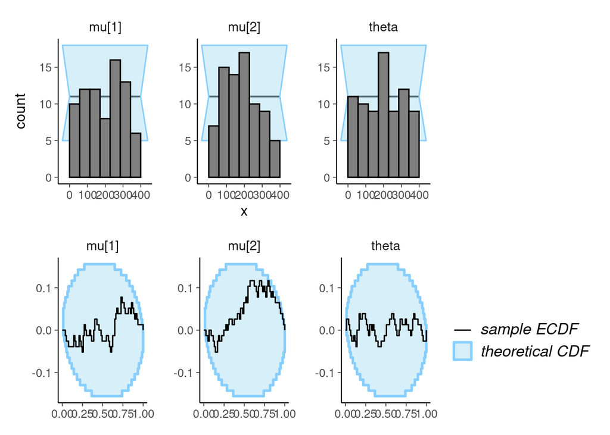

```r
ordered_combined_rank_hist <- plot_rank_hist(results_fixed_ordered_combined)
ordered_combined_ecdf_diff <- plot_ecdf_diff(results_fixed_ordered_combined)
ordered_combined_rank_hist / ordered_combined_ecdf_diff
```

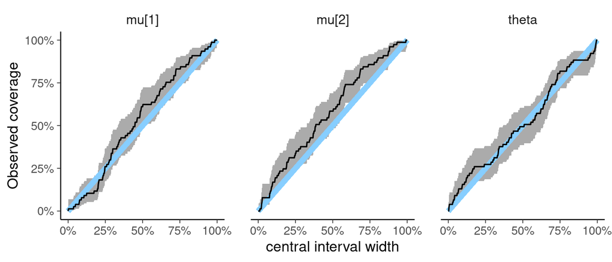

Figure 9: Nominal (light blue) and observed (black) coverage of central posterior intervals for the fixed mixture submodel.

```r
plot_coverage(results_fixed_ordered_combined)
```

Note: it turns out that extending the model to more components becomes somewhat tricky as the model can become sensitive to initialization. Also the problems with data that can be explained by fewer components than the model assumes become more prevalent.

# 3 Logistic regression submodel

Let’s move to the logistic regression submodel of our model.

```r
code_logistic_first <- root("sbc", "models/logistic_first.stan")
```

```r
print_stan_file(code_logistic_first)
```

```stan
data {
  int<lower=0> N_obs;
  array[N_obs] int<lower=0, upper=1> y;
  int<lower=1> N_predictors;
  matrix[N_obs, N_predictors] X;
}
parameters {
  real alpha;
  vector[N_predictors] beta;
}
model {
  target += bernoulli_logit_lpmf(y | X * beta);
  target += normal_lpdf(alpha | 0, 2);
  target += normal_lpdf(beta | 0, 1);
}
```

```r
model_logistic_first <- cmdstan_model(code_logistic_first)
backend_logistic_first <- SBC_backend_cmdstan_sample(model_logistic_first)
```

If you are good at reading code, you may notice there is a fatal bug and fix it, if you do not, we can use simulations to discover the bug.

We also write a matching generator to check that the matrix algebra in the model is correct.

```r
generator_func_logistic_first <- function(N_obs, N_predictors) {
  alpha <- rnorm(1, 0, 2)
  beta <- rnorm(N_predictors, 0, 1)
  X <- matrix(rnorm(N_predictors * N_obs, 0, 1), nrow = N_obs, ncol = N_predictors)
  linpred <- array(alpha, N_obs)
  for (p in 1:N_predictors) {
    linpred <- linpred + X[, p] * beta[p]
  }
  y <- rbinom(N_obs, size = 1, prob = plogis(linpred))
  list(variables = list(alpha = alpha, beta = beta),
       generated = list(N_obs = N_obs, N_predictors = N_predictors, y = y, X = X)
  )
}
generator_logistic_first <- SBC_generator_function(generator_func_logistic_first, N_obs = 50, N_predictors = 2)
```

We’ll start with 20 simulations.

```r
set.seed(31859523)
datasets_logistic_first <- generate_datasets(generator_logistic_first, 20)

results_logistic_first_20 <- compute_SBC(datasets_logistic_first,
                                         backend_logistic_first,
                                         cache_mode = "results",
                                         cache_location = file.path(cache_dir, "logistic_first_20"))
```

```
Results loaded from cache file 'logistic_first_20'
```

Already with 20 datasets we are likely to see suspicious rank/ECDF plots:

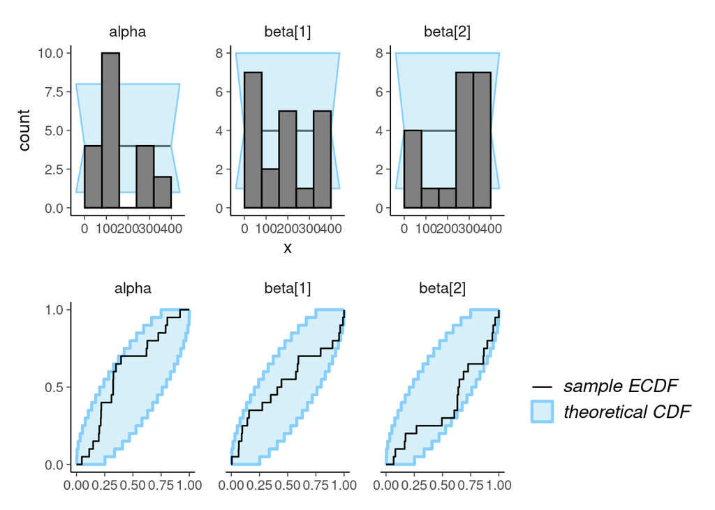

Figure 10: Rank histogram (top) and ECDF plot (bottom) for the first 20 simulations of the logistic submodel.

```r
logistic_first_ranks <- plot_rank_hist(results_logistic_first_20)
logistic_first_ecdf <- plot_ecdf(results_logistic_first_20)
logistic_first_ranks / logistic_first_ecdf
```

At this point, we could use more simulations to see if the discrepancy is real. But this is also a good opportunity to introduce additional ways to diagnose mismatches between the Stan code and the simulator. A simple diagnostic is to plot the simulated values against posterior estimates, which can be done via the `plot_sim_estimated()` function.

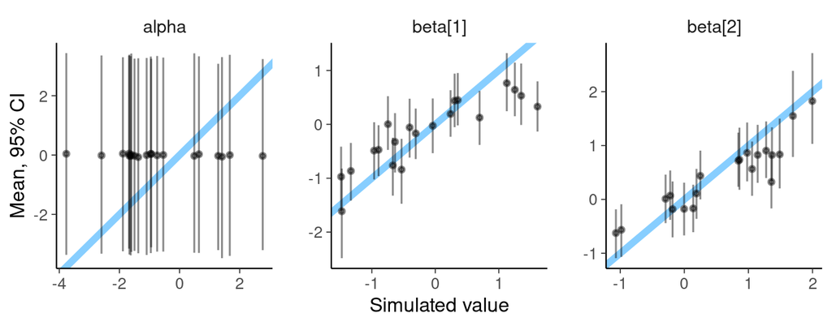

Figure 11: Simulated and estimated values of all parameters for the first 20 simulations of the logistic regression submodel.

```r
logistic_first_sim_estimated <- plot_sim_estimated(results_logistic_first_20) +
  labs(x = "Simulated value", y = "Mean, 95% CI")
logistic_first_sim_estimated
```

One thing that immediately stands out is that the posterior inferences for `alpha` seem to be independent of the simulated value. Indeed, in our Stan code, `alpha` never enters the likelihood part of the model: where we have ``X * beta` we should have had `alpha + X * beta`.

This problem manifests as suspicious rank/ECDF plots for the `beta` parameters. In fact, using this model, SBC will never show a failure for `alpha`, as just sampling from the prior (and ignoring likelihood) will always satisfy the SBC equality *for the parameter*.